# Tuning Neural Networks with R

How do I chose the number of layers in my Neural Network? How many neurons should each layer have and why? Why is this so important?

In the following Kernel I’ll try to boil down questions like these and find understandable answers to them.

# Dataset

MNIST (“Modified National Institute of Standards and Technology”) is the de facto “hello world” dataset of computer vision. Since its release in 1999, this classic dataset of handwritten images has served as the basis for benchmarking classification algorithms. The goal here is to train an algorithm that is capable of labelling the handwritten numbers corretly.

We’ll use this as an opportunity to discuss some details on training and tuning of simple *Neural Networks with R*.

```r
library(tidyverse)
library(data.table)
library(h2o)
library(caret)
library(harrypotter)
library(gridExtra)
h2o.init()
```

[output not shown]

So let’s get started.

# Architecture of a Neural Network

Every Neural Network (NN) has three types of layers: *input*, *output* and *hidden*. Let’s describe them one by one:

## Input Layer

Very simple. Every NN has exactly one *Input Layer*. No more, no less, and no exceptions that I’m aware of.

But, how many neurons has the Input Layer? Can be chosen? Well, no. The number of neurons in an Input Layer is uniquely determined by the number of *features* of your data, plus a bias term.

Wait what? What is a biased term? Actually, not every neural network architecture includes a biased term; but they normally should. This additional node *allows you to shift the activation function*, which can be critical for successful training.

### Bias Term

As you might know by now, neurons in a Neural Network are connected by an activation function. This function is usually a *sigmoid*. Which is defined as follows:

$$S(x) = \frac{1}{1 + e^{-x}}$$

Consider a 1-input, 1-output network that has no bias. The output of the network is computed by multiplying the `input` by the weight $w_1$ and passing the result through the activation function.

We can draw how this function would look like for various values of $w_1$:

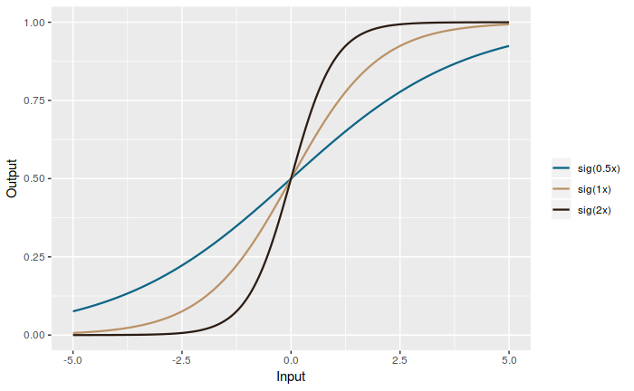

```r
sig <- function(x){
    1 / (1 + exp(-x))
}
x <- seq(-5, 5, 0.01)
tibble(`sig(0.5x)` = sig(0.5*x), `sig(1x)` = sig(x), `sig(2x)` = sig(2*x), input = x) %>%
    melt(id.vars = "input") %>%
    ggplot(aes(y = value, x = input)) +
    geom_line(aes(colour = variable), size = 0.8) +
    scale_colour_hp(discrete = TRUE, house = "Ravenclaw", name = "") +
    xlab("Input") +
    ylab("Output")
```

As you can see, changing the weight $w_1$ basically changes the *steepness* of the sigmoid, not its position. That’s useful, but what if you wanted the network to output $0$ when this neuron outputs $2$. You can’t do that by just changint the steepness. You would want to be able to *shift* the entire curve to the right.

And that is exactly what the bias allows you to do. Our function $sig(w_1x)$ becomes $sig(w_1x_1 + w_0)$. This additional term $w_0$ that has no relationship with any input $x$ gives the network this flexibility.

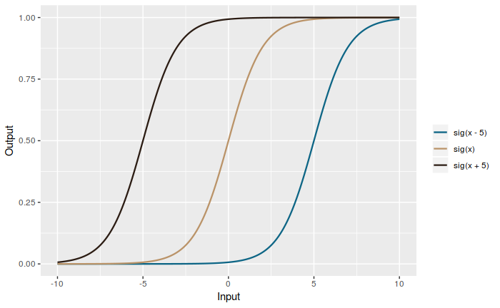

```r
x <- seq(-10, 10, 0.01)
tibble(`sig(x - 5)` = sig(x - 5), `sig(x)` = sig(x), `sig(x + 5)` = sig(x + 5), input = x) %>%
    melt(id.vars = "input") %>%
    ggplot(aes(y = value, x = input)) +
    geom_line(aes(colour = variable), size = 0.8) +
    scale_colour_hp(discrete = TRUE, house = "Ravenclaw", name = "") +
    xlab("Input") +
    ylab("Output")
```

Now that we have this additional term, we are allowed to build a network that is capable of outputting $0$ when the input $x$ is 2. Whereas without the bias term it simply wasn’t possible.

## Output Layer

Like the Input Layer, every NN has just one output layer. And determining its size is just as simple: It is completely determined by the model configuration. It will depend on the kind of *output* the NN is giving.

- If the NN is a *regressor*, the output layer has one single node.
- If the NN is a *classifier*, the output layer has one node per class label in your model.

So in our case, that we want to train the NN to be able to recognize hand-written digits, our output layer would have $10$ nodes. On node per digit, which would output a probability. But what would happen if our NN outputs a probability higher than $0.5$ for more than one digit? Imagine that our NN outputs a probability of $0.87$ for a given instance to be a $7$ and a probability of $0.91$ of being a $1$? (rest possibilities have probability $0$) Numbers $7$ and $1$ can look quite similar in hand-written style, so this example shouldn’t be so rare. How do we handle this situation?

The simplest approach is the most obvious one, we just label the output taking the higher probability. In this case, our NN would label the result as $1$. It is the most probable, right? This is called *Max-Layer Output* and it is actually helpful and solves the problem. But if you had to write down a function for this, it would be tricky - and more importantly - it would be *non-differentiable*.

### Differentiability in NN.

What does *non-differentiable* means, and why is this important for training Neural Networks?

Let’s first understand what differentiable means. A functions is said to be differentiable if its derivative exists at all points ( [More on Differentiable functions](https://en.wikipedia.org/wiki/Differentiable_function) ). Or, as mathematicians like to say: The function is *smooth* and *well behaved*.

When we say that a function is *well behaved*, we usually mean that we don’t expect any sudden jerk in its value, never. This proporety allows us to do pretty fancy stuff, such as extraploate and interpolate the function being reasonably sure that our predictions are close to the real thing. This is something that we assume in our Machine Learning algorithms.

Hence, differentiability is something that we assume to be true in the functions we use in our Neural Networks.

So that strategy about getting the maximum probability on any node within the output layer is non-differentiable. What alternatives do we have? Commonly, what you will see is the so called *Softmax Function*.

### Softmax Function

Softmax function is the fancy name for the normalized exponential function. Which is a generalization of the logistic function that squeezes a multi-dimensional vector of real values into a vector of values between $0$ and $1$ that, together, add up to $1$.

$$P(\vec{x}) = \frac{x^T w_j}{\sum_{k=1}^K e^{x^T w_k}}$$

Don’t run away yet, please. I know this looks scary. You don’t need to get into the details, just get the idea that - effectively - we are just normalizing that max-layer output thing into a smooth function. This way, our previous example would have gotten probabilities of $0.51$ for number $1$ and $0.49$ for number $7$, whilst the rest are $0$. See that we can still chose the highest and label the output correctly, but now they sum up to $1$ and the function that defines them is smooth.

## Hidden Layer

To the interesting stuff: Hidden Layers.

*How many Hidden Layers?*

- If your data is *linearly separable* then you don’t need any hidden layers at all. As a matter of fact, you don’t even need to use a Neural Network for this problem. [Linear Regressions](https://en.wikipedia.org/wiki/Linear_regression) were build for these situations. You should be using them instead. Your Neural Network will be able to do it, but less effectively and with much more computational effort. You are *overkilling*.
- If your variables are more complex than *linear*, let’s say you want to consider *quadratic interactions*, then you are looking for *one hidden layer* configurations.
- If you want to consider *cubic interactions*, you need *two hidden layers* configurations.

See the pattern? For your model to be able to be trained with *K* order interactions, you need a configuration of *K-1* hidden layers. Easy, right? Well, not that much. How do you know the level of interactions your data is showing? That is the tricky part, and that is one of the reasons why everyone is repeating the same mantra to rookies: *Know your data before considering building a Machine Learning algorithm*. And they are very much right.

You could say that it is always safer to build the Neural Network as complex as you can get, overkill your problem and you’ll algorithm will train itself to fit the reality. Better safe than sorry, right? You don’t want to miss a $53$ order interaction by going cheap on Hidden Layers, so let’s roll it and build a huge NN that will do the messy work for you. And you’d be kinda right. But you are going to stump upon two ugly-faced constraints: *Time* and *Generalizability*.

### Guaranteeing Generalizability

One of the biggest concerns of any Machine Learning model is its *Generalizability*. It is an ugly word, I know. What it simply means is the capability of your model to handle equally well data from which it didn’t receive any training. You can train a model to be extremely accurate predicting the outputs of the training data set, whilst being utterly useless predicting anything outside that.

We’ve just found the monster all Machine Learning Engineers are afraid of. The one they all talk about. He’s here! *SIRIUS BLACK !!*

Sorry, just joking. Is not Sirius Black, it’s *Overfitting*. You should already have a broad idea of what *overfitting* means by now. But how this has aneything to do with the number of Hidden Layers? Well, every model is not capable of differentiating *causality* from *coincidence*.

Imagine that you have a medical data set where $70%$ of the patients who died from [Heart Failure](https://www.nhs.uk/conditions/heart-failure/) were left-handed. Would that mean that being left-handed is an important variable in order to prevent heart conditions? Should we ask patients which is their dominant hands for diagnosis? Or is it just a coincidence? A researcher would cautiously publish that *we need more data before stating anything in firm*, or that it lacks *statistical significance*. Which is true in both cases, getting more data is the best way of confirming or discarding this heterogeneity in the data.

If it’s just a coincidence, only present in your data set, most models would learn that af it were a *causal relationship* between that fact and heart conditions, and will extraploate it for future predictions. This will contribute enormously to increase their bias, and thus more misclassifications. You don’t want your model to do that. This *coincidences* is what we usually call *noise* in the data. You don’t want your model to learn the *noise* and get confused on new data.

> “In order to secure the ability of the network to generalize the number of nodes has to be kept as low as possible. If you have a large excess of nodes, you network becomes a memory bank that can recall the training set to perfection, but does not perform well on samples that was not part of the training set.” - Steffen B Petersen · Aalborg University

Increasing the complexity of a Neural Network by adding hidden layers is a great way to overfitting, because it increases the chances of creating variables out of noise. A $53$ degree interaction between the variables is far more likely to be just noise than anything meaningful. But between linear interactions and $53$ there must be some sweetspot where our model is complex enough to gasp the non-obvious relationships, but not so complex to get fooled by noise. How do we get to that point?

There are a myriaf of exotic techniques in order to avoid that. You can do some regularization, check your generalizability by Cross Validation, dropping out some neurons on the way of training your Neural Network, etc. But today I want to stick to the simple stuff. We are building a feeding-forward Neural Network and we want to chose the proper amount of neurons and hidden layers in our architecture, and stick with that. Once we master this simple stuff, we’ll get more fancy and build smarter configurations.

Now that we have an idea of how to address the *number of hidden layers*, we should focus on the *number of neurons* in each hidden layer. There are some dicussion in this topic, and I won’t enter into many details. A general rule of thumb that I like to apply in order to decide the *total* number of neurons in the hidden layers, is this following formula:

$$N_h = \frac{n_sN_o}{\alpha N_i}$$

Where

- $N_i$ is the number of *input* neurons.
- $N_o$ is the number of *output* neurons.
- $n_s$ is the number of *samples* in the training data set.
- $\alpha$ is an arbitrary scaling factor between 1 and 10.

This not solves the problem by itself, but now it is boiled down. Our concern would be to decide which is the $\alpha$, which is much simpler.

Now we are going to build Neural Networks using this rule of thumb and evaluate an optimal value for $\alpha$.

We load the data,

```r
digit <- fread("data/train.csv") %>%
    mutate(label = as.factor(label))
```

Our $n_s$ will be the number of instances:

```r
n_instances <- nrow(digit)
n_s <- n_instances
```

The value for $N_o$ is going to be simply the number of possible solutuions of our problem:

```r
N_o <- digit$label %>% unique() %>% length()
```

The value of our $N_i$ needs to be the number of variables plus the bias term. And the number of variables is the number of columns minus the `label`, so

```r
N_i <- ncol(digit) - 1 + 1
```

So the number of neurons present in hidden layers will be:

```r
alpha <- seq(1,10, by=0.1)
N_h <- n_s*N_o/(alpha*N_i)
N_h
```

```
 [1] 535.03185 486.39259 445.85987 411.56296 382.16561 356.68790 334.39490 314.72462 297.23992 281.59571 267.51592 254.77707 243.19629 232.62254
[15] 222.92994 214.01274 205.78148 198.15994 191.08280 184.49374 178.34395 172.59092 167.19745 162.13086 157.36231 152.86624 148.61996 144.60320
[29] 140.79785 137.18765 133.75796 130.49557 127.38854 124.42601 121.59815 118.89597 116.31127 113.83656 111.46497 109.19017 107.00637 104.90821
[43] 102.89074 100.94941  99.07997  97.27852  95.54140  93.86524  92.24687  90.68336  89.17197  87.71014  86.29546  84.92569  83.59873  82.31259
[57]  81.06543  79.85550  78.68115  77.54085  76.43312  75.35660  74.30998  73.29203  72.30160  71.33758  70.39893  69.48466  68.59383  67.72555
[71]  66.87898  66.05331  65.24779  64.46167  63.69427  62.94492  62.21301  61.49791  60.79907  60.11594  59.44798  58.79471  58.15564  57.53031
[85]  56.91828  56.31914  55.73248  55.15792  54.59509  54.04362  53.50318
```

And then we train and evaluate the different Neural Networks:

```r
acc_tr <- c()
acc_val <- c()
for(i in 1:length(alpha)){
    m <- sample(seq(from = 1, to = n_instances), n_instances*0.8, replace = FALSE)
    train <- digit[m,]
    val   <- digit[-m,]
    h2o_train <- as.h2o(train)
    h2o_val   <- as.h2o(val)

    neurons_layer <- ceiling(N_h[[i]]/3)
    h2o_model <- h2o.deeplearning(x = setdiff(names(train), c("label")),
                                                                y = "label",
                                                                training_frame = h2o_train,
                                                                standardize = TRUE,
                                                                hidden = c(neurons_layer,neurons_layer,neurons_layer),
                                                                rate = 0.05,
                                                                epochs = 10)

    predictions_val   <- as.data.frame(h2o.predict(h2o_model, h2o_val))
    predictions_train <- as.data.frame(h2o.predict(h2o_model, h2o_train))
    acc_tr[i]         <- confusionMatrix(predictions_train$predict, train$label) %>% .$overall %>% .["Accuracy"] %>% .[[1]]
    print(acc_val[i]  <- confusionMatrix(predictions_val$predict, val$label) %>% .$overall %>% .["Accuracy"] %>% .[[1]])
}
```

```
Dropping bad and constant columns: [pixel729, pixel644, pixel645, pixel448, pixel725, pixel726, pixel727, pixel728, pixel560, pixel52, pixel760, pixel10, pixel54, pixel53, pixel168, pixel56, pixel11, pixel55, pixel57, pixel16, pixel18, pixel17, pixel19, pixel754, pixel755, pixel756, pixel757, pixel7…
rate cannot be specified if adaptive_rate is enabled..
```

[figure not shown]

What do you see in the results?

# Facing *Time* Constraints

One of the limitations that should concern the real-world applicability of Neural Network models is the training time. Even though this dataset is small and time shouldn’t be an issue, it is interesting to highlight how much time it *costs* us to increase the accuracy of a model. It is usual to think that higher accuracy is always worth the time the model needs to train. Which is normally the case in Kaggle Competitions, but not so in some business applications. In some scenarios, time matters.

Now we are going to measure how the accuracy of a model increases by increasing its complexity. The more complex the more accurate (in this example), but the longer it takes to compute.

In order to measure it, we’ll just train a simple Neural Network usuing the `h2o` package and use it for different levels of complexity. We are going to evaluate the performance of our model in a validation set and we’ll write down how much time it took every time.

```r
digit <- fread("data/train.csv") %>%
    mutate(label = as.factor(label))
```

```r
n_iters <- 1e2
n_instances <- nrow(digit)
acc <- c()
time <- c()

for(i in 1:n_iters){
    m <- sample(seq(from = 1, to = n_instances), n_instances*0.8, replace = FALSE)
    train <- digit[m,]
    val   <- digit[-m,]
    h2o_train <- as.h2o(train)
    h2o_val   <- as.h2o(val)

    time[i] <- system.time({
        h2o_model <- h2o.deeplearning(x = setdiff(names(train), c("label")),
                                                                y = "label",
                                                                training_frame = h2o_train,
                                                                standardize = TRUE,
                                                                hidden = c(10 + i*2,10 + i*2,10 + i*2),
                                                                rate = 0.05,
                                                                epochs = 10)
    })[1][[1]]
    h2o_predictions <- as.data.frame(h2o.predict(h2o_model, h2o_val))
    print(acc[i] <- confusionMatrix(h2o_predictions$predict, val$label) %>% .$overall %>% .["Accuracy"] %>% .[[1]])
}

results_time <- tibble(Accuracy = acc, Time = time, Iteration = 1:n_iters)
```

[output not shown]